# Customizable Annotated Forest Plots in R using ggplot2

Katherine Hoffman

2022-08-12T21:13:14-05:00

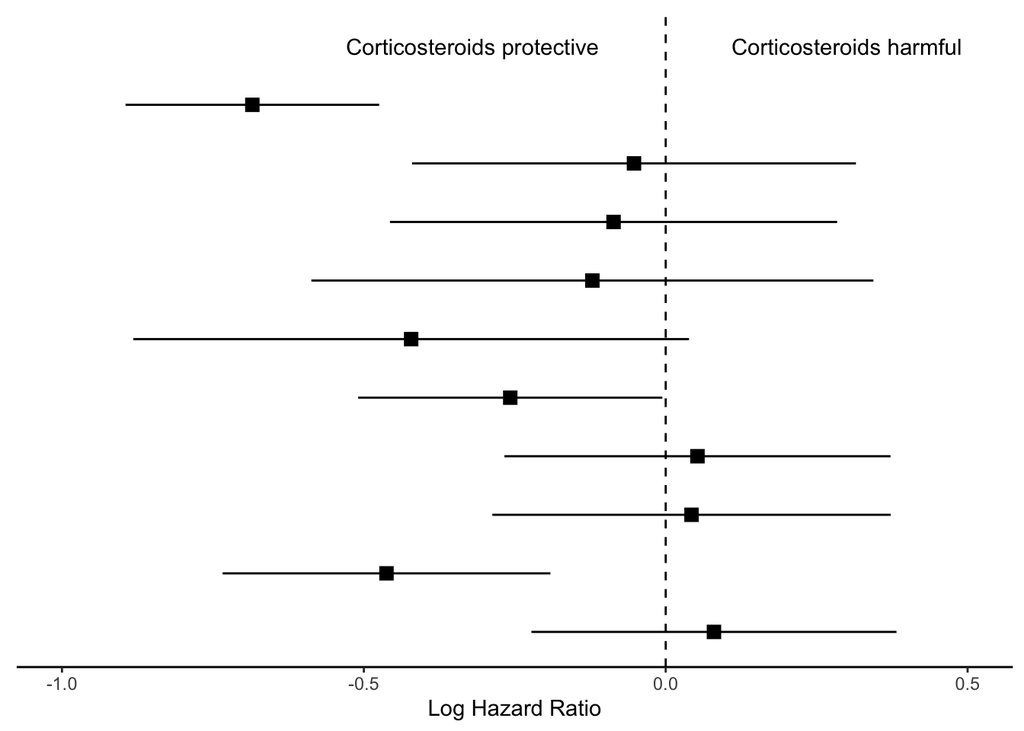

```r
## load up the packages we will need:

library(tidyverse)
library(gt)
library(patchwork)

## ---------------------------

## load data

githubURL <- ("https://raw.githubusercontent.com/kathoffman/steroids-trial-emulation/main/output/model-first-results-log.rds")
download.file(githubURL,"model-first-results-log.rds", method="curl")
res_log <- readRDS("model-first-results-log.rds")

githubURL <- ("https://raw.githubusercontent.com/kathoffman/steroids-trial-emulation/main/output/model-first-results.rds")
download.file(githubURL,"model-first-results.rds", method="curl")
res <- readRDS("model-first-results.rds")


# load in results generated from Cox PH hazards models
#res_log <- read_rds(here::here('content', "blog","forest_plots","model-first-results-log.rds"))
#res <- read_rds(here::here('content', "blog","forest_plots","output/model-first-results.rds"))

## plotting

## ---------------------------

# create forest plot on log scale (middle section of figure)
p_mid<-
  res_log %>%
  ggplot(aes(y = model)) +
  geom_point(aes(x=estimate), shape=15, size=3) +
  geom_linerange(aes(xmin=conf.low, xmax=conf.high)) +
  labs(x="Log Hazard Ratio") +
  theme_classic() +
  scale_y_discrete() +
  coord_cartesian(ylim=c(1,11), xlim=c(-1, .5))+
  geom_vline(xintercept = 0, linetype="dashed") +
  scale_colour_identity() +
  theme(axis.line.y = element_blank(),
        axis.ticks.y= element_blank(),
        axis.text.y= element_blank(),
        axis.title.y= element_blank())+
  annotate("text", x = -.32, y = 11, label = "Corticosteroids protective") +
  annotate("text", x = .3, y = 11, label = "Corticosteroids harmful")
p_mid
```

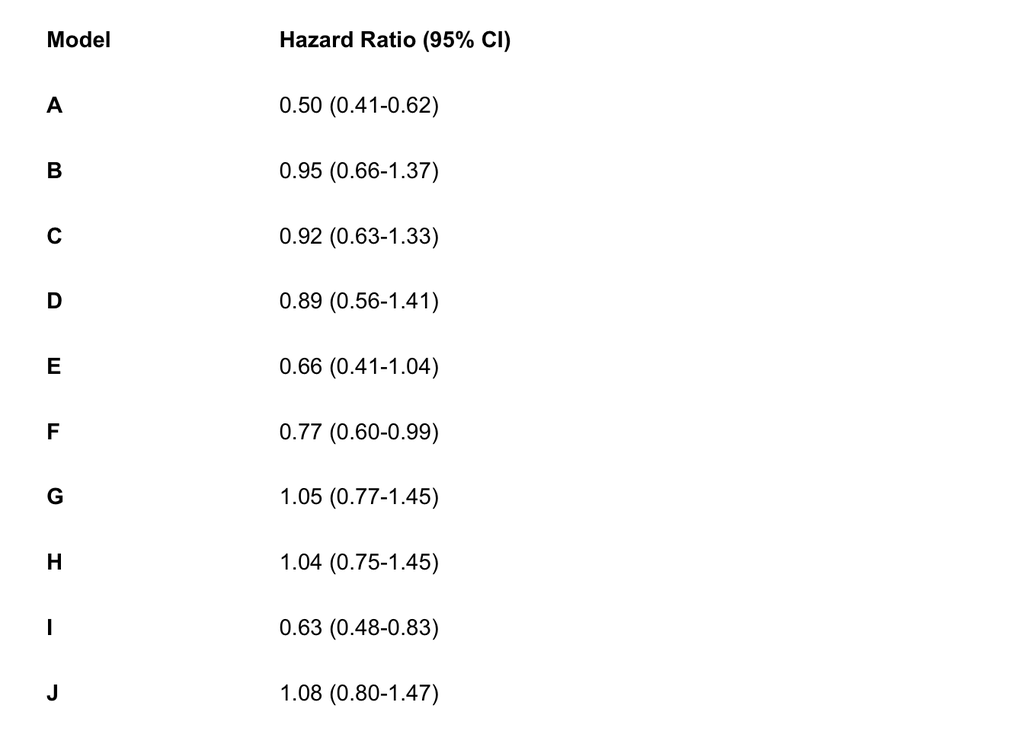

```r
# wrangle results into pre-plotting table form
res_plot <- res %>%
  mutate(across(c(estimate, conf.low, conf.high), ~str_pad(round(.x, 2), width=4, pad="0", side="right")),
         estimate_lab = paste0(estimate, " (", conf.low, "-", conf.high,")"),
         color = rep(c("gray","white"),5)) %>%
  mutate(p.value = case_when(p.value < .01 ~ "<0.01", TRUE ~ str_pad(as.character(round(p.value, 2)),width=4,pad="0",side="right"))) %>%
  bind_rows(data.frame(model = "Model", estimate_lab = "Hazard Ratio (95% CI)", conf.low = "", conf.high="",p.value="p-value")) %>%
  mutate(model = fct_rev(fct_relevel(model, "Model")))

# left side of plot - hazard ratios
p_left <-
  res_plot  %>%
  ggplot(aes(y = model)) +
  geom_text(aes(x=0, label=model), hjust=0, fontface = "bold") +
  geom_text(aes(x=1, label=estimate_lab), hjust=0, fontface = ifelse(res_plot$estimate_lab == "Hazard Ratio (95% CI)", "bold", "plain")) +
  theme_void() +
  coord_cartesian(xlim=c(0,4))
p_left
```

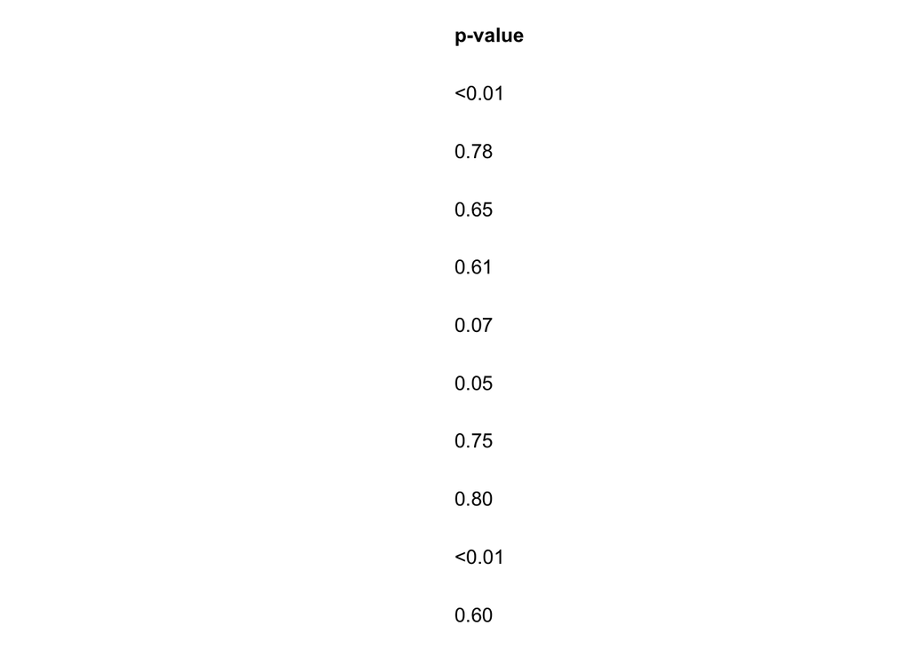

```r
# right side of plot - pvalues
p_right <-
  res_plot  %>%
  ggplot() +
  geom_text(aes(x=0, y=model, label=p.value), hjust=0, fontface = ifelse(res_plot$p.value == "p-value", "bold", "plain")) +
  theme_void()
p_right
```

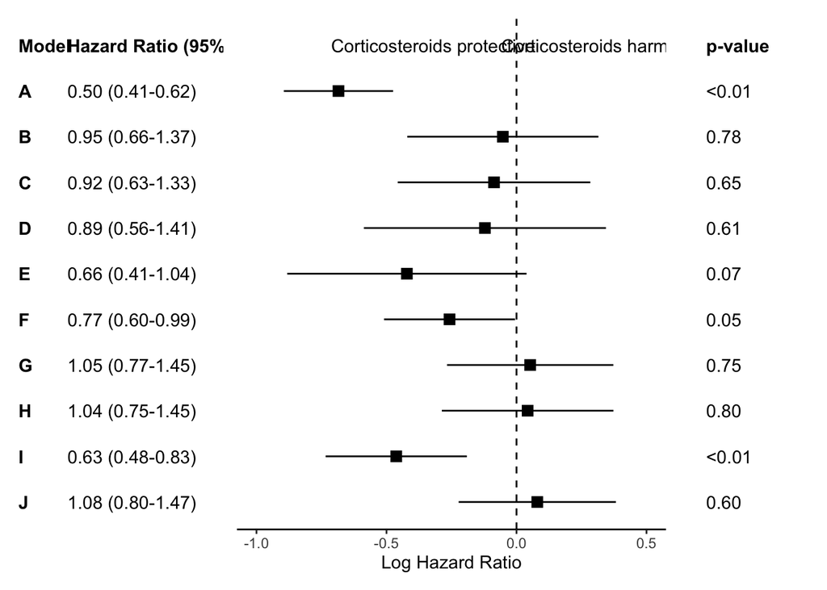

```r
# layout design (top, left, bottom, right)
layout <- c(
  area(t = 0, l = 0, b = 30, r = 3),
  area(t = 1, l = 4, b = 30, r = 9),
  area(t = 0, l = 9, b = 30, r = 11)
)

# final plot arrangement
p_left + p_mid + p_right + plot_layout(design = layout)
```

```r
## save final figure
# ggsave("manuscript/figure-3.eps", width=9, height=4)
```

R version 4.1.3 (2022-03-10) Platform: x86_64-apple-darwin17.0 (64-bit) Running under: macOS Catalina 10.15.7

locale: [1] en_US.UTF-8/en_US.UTF-8/en_US.UTF-8/C/en_US.UTF-8/en_US.UTF-8

attached base packages: [1] stats graphics grDevices utils datasets methods base

other attached packages: [1] patchwork_1.1.1 gt_0.6.0 forcats_0.5.1 stringr_1.4.0  
[5] dplyr_1.0.9 purrr_0.3.4 readr_2.1.2 tidyr_1.2.0  
[9] tibble_3.1.6 ggplot2_3.3.5 tidyverse_1.3.1